# EDA

# Generic rules

## Definition

### Agglomerative approach:

- find closest two things
- put them ogtether
- find next closer

### Requires

- defined distance
- merging approach

### Produces

- tree showing how close things are to each other

### How do we deine close:

- garbage in -> garbage out
- Distance or similarity
  - euclidian
  - continuous
  - binary

### Example :

- Manhattan distance

## Practice

### Generate dataset example

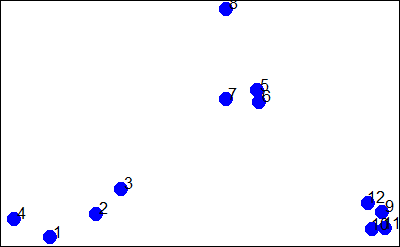

```r
set.seed(1234)
par(mar = c(0,0,0,0))
x <- rnorm(12, mean = rep(1:3, each = 4), sd=0.2)
y <- rnorm(12, mean = rep(c(1,2,1), each = 4), sd=0.2)
plot(x,y,col="blue", pch=19, cex=2)
text(x + 0.05, y + 0.05, labels=as.character(1:12))
```

### Generate dataframe

```r
dataFrame <- data.frame(x,y)
dist(dataFrame)
```

```
            1          2          3          4
2  0.34120511
3  0.57493739 0.24102750
4  0.26381786 0.52578819 0.71861759
5  1.69424700 1.35818182 1.11952883 1.80666768
6  1.65812902 1.31960442 1.08338841 1.78081321
7  1.49823399 1.16620981 0.92568723 1.60131659
8  1.99149025 1.69093111 1.45648906 2.02849490
9  2.13629539 1.83167669 1.67835968 2.35675598
10 2.06419586 1.76999236 1.63109790 2.29239480
11 2.14702468 1.85183204 1.71074417 2.37461984
12 2.05664233 1.74662555 1.58658782 2.27232243
            5          6          7          8
2
3
4
5
6  0.08150268
7  0.21110433 0.21666557
8  0.61704200 0.69791931 0.65062566
9  1.18349654 1.11500116 1.28582631 1.76460709
10 1.23847877 1.16550201 1.32063059 1.83517785
11 1.28153948 1.21077373 1.37369662 1.86999431
12 1.07700974 1.00777231 1.17740375 1.66223814
            9         10         11
2
3
4
5
6
7
8
9
10 0.14090406
11 0.11624471 0.08317570
12 0.10848966 0.19128645 0.20802789
```

#### hClust

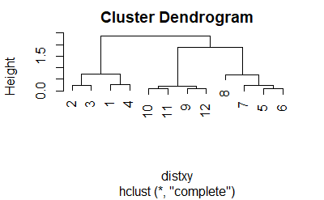

#### Prettier dendrogram

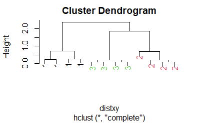

### HeatMap

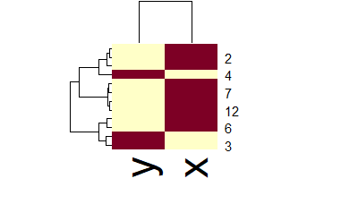

### K-means

Same for clusering general definiton, how do we define close…

Partitionning apporach - Fix a number of clusters - Get centroïds of each cluster - Assign things to closest centroïd - recalculate centroïds

Requires - A defined distance metric - numùber of clusters - an intial gusse of centroïds location

Produces: - Final centroid locaotion - assignement of each points to cluster

```r
kmeansDF
```

```
K-means clustering with 3 clusters of sizes 4, 4, 4

Cluster means:
          x         y
1 2.8534966 0.9831222
2 1.9906904 2.0078229
3 0.8904553 1.0068707

Clustering vector:
 [1] 3 3 3 3 2 2 2 2 1 1 1 1

Within cluster sum of squares by cluster:
[1] 0.03298027 0.34732441 0.34188313
 (between_SS / total_SS =  93.6 %)

Available components:

[1] "cluster"      "centers"      "totss"        "withinss"
[5] "tot.withinss" "betweenss"    "size"         "iter"
[9] "ifault"
```

### HeatMap

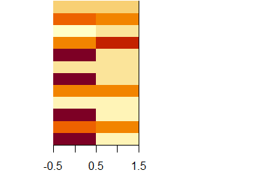

```r
kmeansDF <- kmeans(dataMatrix, centers = 3)
par(mfrow = c(1,2), mar=c(2,4,0.1,0.1))
image(t(dataMatrix)[, nrow(dataMatrix):1], yaxt = "n")
image(t(dataMatrix)[, order(kmeansDF$cluster)], yaxt = "n")
```